# **R PROGRAMMING ASSIGNMENT**

#### **NAME:** HITESH KISHOR CHAUDHARI

#### **PRN:** 210940125013

**The dataset has been downloaded from the following link: [*Link*](https://www.kaggle.com/fedesoriano/heart-failure-prediction)**

**Click here to view the Dataset**

| Age | Sex | ChestPainType | RestingBP | Cholesterol | FastingBS | RestingECG | MaxHR | ExerciseAngina | Oldpeak | ST_Slope | HeartDisease |
| --- | --- | --- | --- | --- | --- | --- | --- | --- | --- | --- | --- |
| 40 | M | ATA | 140 | 289 | 0 | Normal | 172 | N | 0.0 | Up | 0 |
| 49 | F | NAP | 160 | 180 | 0 | Normal | 156 | N | 1.0 | Flat | 1 |
| 37 | M | ATA | 130 | 283 | 0 | ST | 98 | N | 0.0 | Up | 0 |
| 48 | F | ASY | 138 | 214 | 0 | Normal | 108 | Y | 1.5 | Flat | 1 |
| 54 | M | NAP | 150 | 195 | 0 | Normal | 122 | N | 0.0 | Up | 0 |
| 39 | M | NAP | 120 | 339 | 0 | Normal | 170 | N | 0.0 | Up | 0 |
| 45 | F | ATA | 130 | 237 | 0 | Normal | 170 | N | 0.0 | Up | 0 |
| 54 | M | ATA | 110 | 208 | 0 | Normal | 142 | N | 0.0 | Up | 0 |
| 37 | M | ASY | 140 | 207 | 0 | Normal | 130 | Y | 1.5 | Flat | 1 |
| 48 | F | ATA | 120 | 284 | 0 | Normal | 120 | N | 0.0 | Up | 0 |
| 37 | F | NAP | 130 | 211 | 0 | Normal | 142 | N | 0.0 | Up | 0 |
| 58 | M | ATA | 136 | 164 | 0 | ST | 99 | Y | 2.0 | Flat | 1 |
| 39 | M | ATA | 120 | 204 | 0 | Normal | 145 | N | 0.0 | Up | 0 |
| 49 | M | ASY | 140 | 234 | 0 | Normal | 140 | Y | 1.0 | Flat | 1 |
| 42 | F | NAP | 115 | 211 | 0 | ST | 137 | N | 0.0 | Up | 0 |
| 54 | F | ATA | 120 | 273 | 0 | Normal | 150 | N | 1.5 | Flat | 0 |
| 38 | M | ASY | 110 | 196 | 0 | Normal | 166 | N | 0.0 | Flat | 1 |
| 43 | F | ATA | 120 | 201 | 0 | Normal | 165 | N | 0.0 | Up | 0 |
| 60 | M | ASY | 100 | 248 | 0 | Normal | 125 | N | 1.0 | Flat | 1 |
| 36 | M | ATA | 120 | 267 | 0 | Normal | 160 | N | 3.0 | Flat | 1 |
| 43 | F | TA | 100 | 223 | 0 | Normal | 142 | N | 0.0 | Up | 0 |
| 44 | M | ATA | 120 | 184 | 0 | Normal | 142 | N | 1.0 | Flat | 0 |
| 49 | F | ATA | 124 | 201 | 0 | Normal | 164 | N | 0.0 | Up | 0 |
| 44 | M | ATA | 150 | 288 | 0 | Normal | 150 | Y | 3.0 | Flat | 1 |
| 40 | M | NAP | 130 | 215 | 0 | Normal | 138 | N | 0.0 | Up | 0 |
| 36 | M | NAP | 130 | 209 | 0 | Normal | 178 | N | 0.0 | Up | 0 |
| 53 | M | ASY | 124 | 260 | 0 | ST | 112 | Y | 3.0 | Flat | 0 |
| 52 | M | ATA | 120 | 284 | 0 | Normal | 118 | N | 0.0 | Up | 0 |
| 53 | F | ATA | 113 | 468 | 0 | Normal | 127 | N | 0.0 | Up | 0 |
| 51 | M | ATA | 125 | 188 | 0 | Normal | 145 | N | 0.0 | Up | 0 |

[output cut: 888 more lines]

**1. Considering the categorical variable RestingECG and numerical variable MaxHR, perform one-way ANOVA for means of MaxHR for every category for RestingECG namely, Normal, ST and LVH. Also perform Tukey’s test and write the conclusion of both the hypothesis tests.**

```
## Analysis of Variance Table
##
## Response: MaxHR
##             Df Sum Sq Mean Sq F value    Pr(>F)
## RestingECG   2  19558  9778.9  15.565 2.253e-07 ***
## Residuals  915 574868   628.3
## ---
## Signif. codes:  0 '***' 0.001 '**' 0.01 '*' 0.05 '.' 0.1 ' ' 1
```

```
##   Tukey multiple comparisons of means
##     95% family-wise confidence level
##
## Fit: aov(formula = MaxHR ~ RestingECG, data = hdf)
##
## $RestingECG
##                  diff       lwr        upr     p adj
## Normal-LVH  -5.814485 -10.78329 -0.8456839 0.0168609
## ST-LVH     -14.499044 -20.65274 -8.3453506 0.0000001
## ST-Normal   -8.684559 -13.75641 -3.6127121 0.0001862
```

**Click here to view the Conclusion**

**Conclusion from ANOVA TEST:-** As p-value(2.253e-07) < alpha(0.05) Hence Rejecting H0. We can say means of categories of RestingECG are not same. At least one of them is different.

**Conclusion from TUKEY TEST:-** All p-values of Normal,ST,LVH are less than alpha. Hence we can that mean values of all categories of RestingECG might be different.

**Click here to view the Code**

```r
hdf <- read.csv("heart.csv",stringsAsFactors = T)
anv <- aov(MaxHR~RestingECG,data=hdf)
anova(anv)
TukeyHSD(anv)
```

**2. Calculate mean MaxHR grouped by values in variable RestingECG namely, Normal, ST and LVH. Generate bar graph for the grouped means generated.**

[figure not shown]

**Click here to view the Code**

```r
library("tidyverse")
hr <- read.csv("heart.csv",stringsAsFactors = T)
hr %>%
  group_by(RestingECG)  %>%
  summarize(MaxHR_mean = mean(MaxHR, na.rm = TRUE))->su
  ggplot(su,aes(RestingECG,MaxHR_mean))+
  geom_bar(aes(fill=MaxHR_mean),stat='identity')+
  labs(title=" Mean MaxHR grouped by RestingECG",x = "RestingECG" ,y = "MaxHR_mean")+
  theme(plot.title = element_text(hjust = 0.5))
```

**3. Perform two independent samples variance and means tests for value of variable age for two different sex categories namely, Male and Female and write the conclusion of both the hypothesis tests.**

```
##
##  F test to compare two variances
##
## data:  male and female
## F = 0.975, num df = 724, denom df = 192, p-value = 0.8079
## alternative hypothesis: true ratio of variances is not equal to 1
## 95 percent confidence interval:
##  0.7723434 1.2125628
## sample estimates:
## ratio of variances
##          0.9749987
```

```
##
##  Two Sample t-test
##
## data:  male and female
## t = 1.6899, df = 916, p-value = 0.9543
## alternative hypothesis: true difference in means is less than 0
## 95 percent confidence interval:
##      -Inf 2.546547
## sample estimates:
## mean of x mean of y
##  53.78207  52.49223
```

**Click here to view the Conclusion**

**Conclusion 1:-**  
As p=0.807 > alpha = .05 There is no difference in variance of age of Male and Female, so performing one tail test

**Conclusion 2:-** As p=0.9543 > alpha =0.05 accept H0: mu1 >= mu2 is accepted Hence we can say age of Male is greater than or equal to Female

**Click here to view the Code**

```r
df <- read.csv("heart.csv")
male <- df[df$Sex=='M','Age']
female <- df[df$Sex=='F','Age']
var.test(male,female)
t.test(male,female,mu=0,var.equal = T,alternative='l')
```

**4. Calculate mean MaxHR grouped by values in variable HeartDisease namely 1 and 0. Generate bar graph for the grouped means generated.**

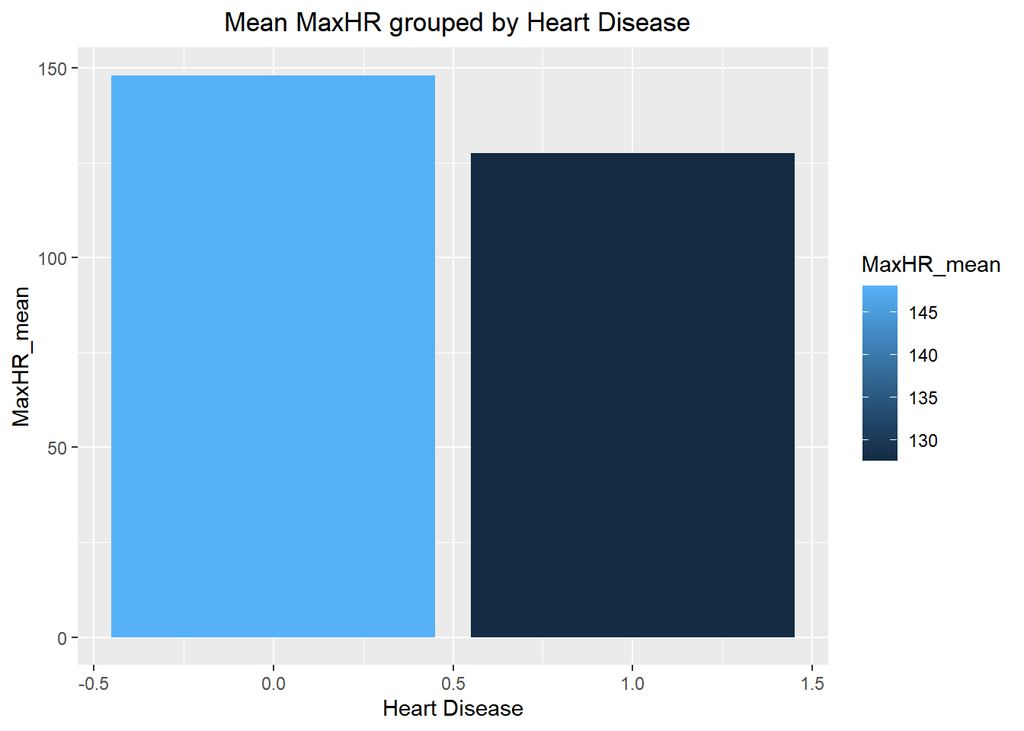

**Click here to view the Code**

```r
library("tidyverse")
hdf <- read.csv("heart.csv",stringsAsFactors = T)
hdf %>%
  group_by(HeartDisease)  %>%
  summarize(MaxHR_mean = mean(MaxHR, na.rm = TRUE))->su)
ggplot(su,aes(HeartDisease,MaxHR_mean))+
  geom_bar(aes(fill=MaxHR_mean),stat='identity')+
  labs(title=" Mean MaxHR grouped by Heart Disease",x = "Heart Disease" ,y = "MaxHR_mean")+
  theme(plot.title = element_text(hjust = 0.5))
```

**5. Generate scatter plot with X axis as RestingBP and Y axis as MaxHR with the different coloursgiven to the categories of variable HeartDisease. You will have to convert the variable HeartDisease into factor before generating the graph.**

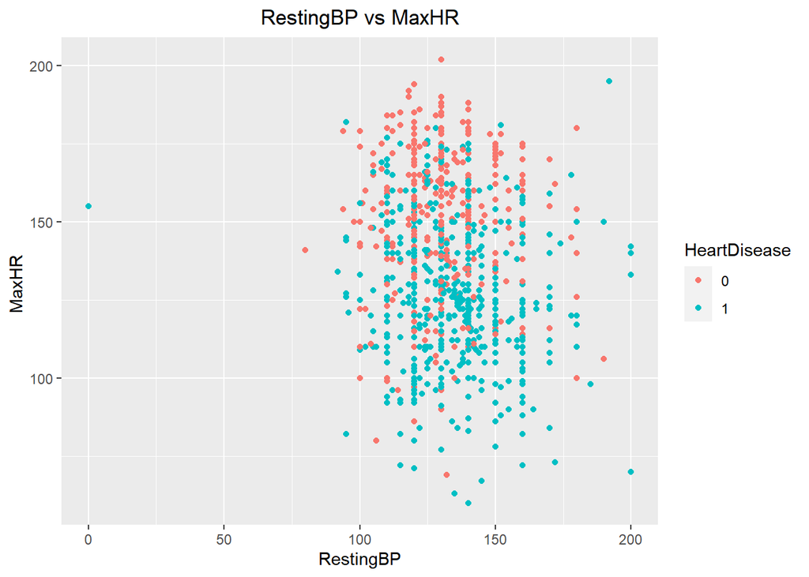

**Click here to view the Code**

```r
library("tidyverse")
hdf <- read.csv("heart.csv",stringsAsFactors = T)
hdf$HeartDisease <- factor(hdf$HeartDisease)
ggplot(hdf, aes(RestingBP, MaxHR , color = HeartDisease)) +
  geom_point() +
  labs(title = "RestingBP vs MaxHR") +
  labs(x = "RestingBP", y = "MaxHR ") +
  theme(plot.title = element_text(hjust = 0.5))
```